# Time Series Analysis

Victoria Jones

April 20, 2020

## Contents

1. Main Concepts
2. Modeling Toolkits
   - 2.1 Fourier Analysis
   - 2.2 Wavelets
   - 2.3 Digital Filtering
3. Summary
4. Research Application

## 1. Main Concepts

#### Astronomical Applications:

- Detection of variability and periodicity
- Treatment of nonperiodic variability
- Searches for localized events

Exoplanet Searches, Variable Stars, Supernovae, Active Galactic Nuclei, Gamma Ray Bursts, Gravitational Wave Events, etc.

Variables: $(t_{1},y_{1}), ... , (t_{n},y_{n})$

- Similar to regression analysis (replace $t$ with $x$), except each $y$ depends on the previous value of $y$

#### Main Tasks:

1. Characterize the correlation and significance between different values of $y$
2. Predict future values of $y$

### Types of Variability:

1. **Periodic** -- regular and predicatable such as RR Lyrae and Cepheid Variables
2. **Stochastic** -- changes are always there but are not predictiable for an indefinite period such as AGN
3. **Localized** -- bursts such as solar flares, supernovae, GRBs, gravitational wave events

(will be discussed in greater detail in the following two lectures)

## 2. Modeling Toolkits

Main set of toolkits either belong to the time or frequency domain

**Time Domain:**

- Signal Detection: Parameter Estimation, Regression, Classification Methods
- Modeling: Bayesian Model odds ratio, AIC criteria, BIC criteria

**Frequency Domain:**

- Fourier Analysis
- Discrete Fourier Transforms
- Wavelet Analysis
- Digital Filtering

## 2.1 Fourier Analysis

### Definitions

In words: general, complicated functions are representated/approximated by integrals/sums of simpler trigonometric functions

Mathematical Definition for function $h(t)$:

Fourier Transform:

#### $H(f) = \int_{-\infty}^{\infty} h(t)e^{(-i2\pi ft)}\mathrm{d}t$

Inverse Fourier Transform:

#### $h(t) = \int_{-\infty}^{\infty} H(f)e^{(i2\pi ft)}\mathrm{d}f$

Work really well with periodic time series data

Example: RR Lyrae Light Curve

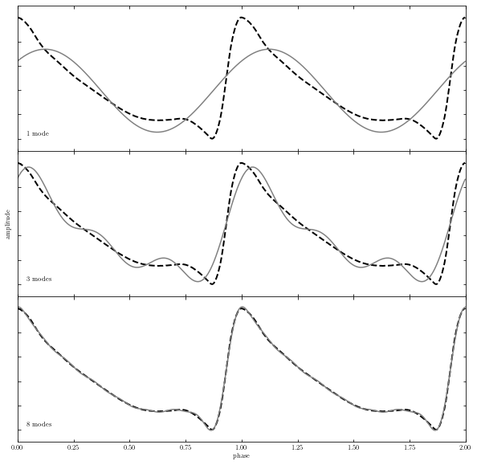

### Convolution Theorem (Smoothing):

A convolution of two functions $a(t)$ and $b(t)$ is given by

#### $(a*b)(t) = \int_{-\infty}^{\infty} a(t')b(t-t')\mathrm{d}t'$

**Astronomical Implication:**

- Ground-based imaging convolves the true intensity distribution on the sky with atmospheric seeing (equavalent to diffraction patterns in space); ie. resolution is never infinite

**Fourier Transform Application:**

If $h = a*b$ then the Fourier Transforms are all related by their pointwise products:

#### $H(f) = A(f)B(f)$

To obtain original signal, $b$, take the inverse Fourier transform of the ratio $H(f)/A(f)$

**Note:** Choose the function you use to convolve your data wisely

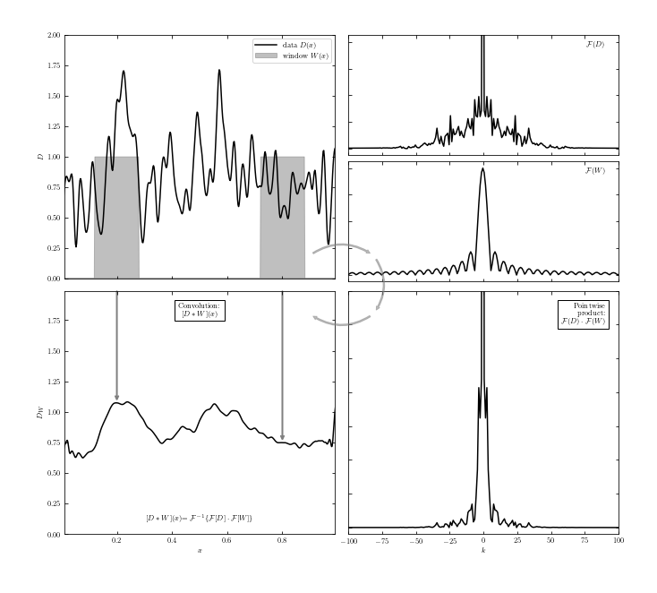

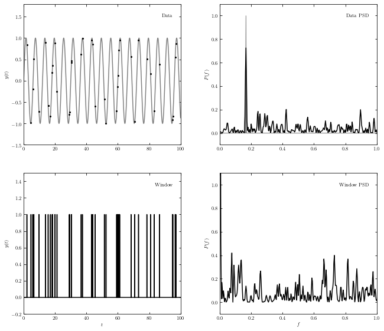

### Discrete Fourier Transform

- Data is always directly sampled -- need a way to transform previously defined Fourier Transforms into discrete applications
- When binned, such as when using CCDs, our h(t) function becomes sampled at N equal intervals such that $h_j = h(t_j)$; $t_j = t_0 +j\Delta t$, $j = 0, ... , (N-1)$

Discrete Fourier Transform:

#### $H_k = \sum_{j=0}^{N-1} h_je^{(-i2\pi jk / N)}$

Discrete Inverse Fourier Transform:

#### $h_j = \frac{1}{N}\sum_{k=0}^{N-1} H_ke^{(i2\pi jk / N)}$

where $k = 0, ... , (N-1)$

### Fast Fourier Transform (FFT)

**Definition:** Algorithm for computing discrete Fourier Transforms in $\mathcal O(N\mathrm{log}N)$ time rather than $\mathcal O(N^2)$

**Astronomical Implication:** Due to its much faster speed than traditional discrete Fourier Transforms it's widely used with analyzing evenly sampled, high signal-to-noise ratio, time series data such as LIGO data

**Common FFT Method:** Welch's Method -- computes multiple Fourier Transforms over overlapping windows of the data to smooth noise effects in the resulting spectrum as seen in LIGO example

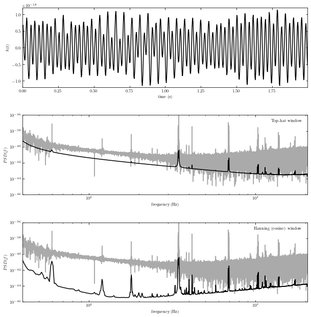

## 2.2 Wavelets

- Fourier Transforms don't work well with nonperiodic time series analysis (especially bursts) since they're based in infinite trigonometric functions
- Could evaluate Fourier Transforms in short bursts but this breaks down with degraded spectral resolution and is biased depending on the choice of time series segmentation length
- Wavelets present one way to handle nonperiodic time series analysis

**Definition:** basis functions that are localized in both frequency and time domains

#### $w(t|t_0, f_0, Q) = A e^{(i2\pi f_0(t-t_0))}e^{(-f_0^2(t-t_0)^2/Q^2)}$

where $t_0$ is the central time, $f_0$ is the central frequency, and $Q$ (dimensionless) is a model parameter which controls the width of the frequency window

Wavelet Transform:

#### $H_w(t_0;f_0,Q) = \int_{-\infty}^{\infty}h(t)w(t|t_0, f_0,Q)$

**Note:** By the true mathematical definition of wavelets this equation is actually off by a scaling factor; however, the textbook uses it to focus on the main goal when using wavelets -- localization in time and frequency

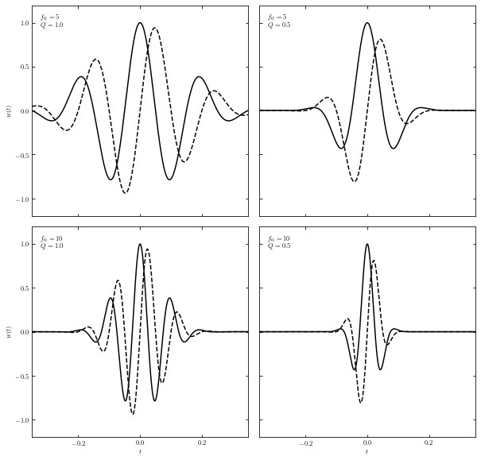

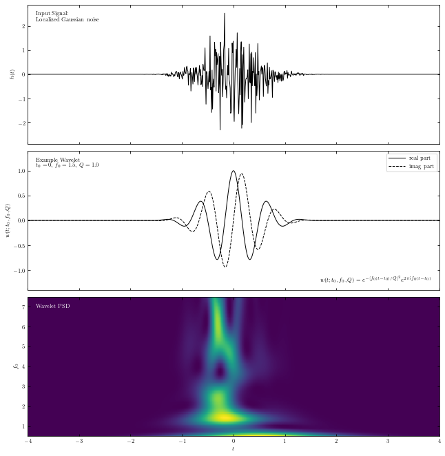

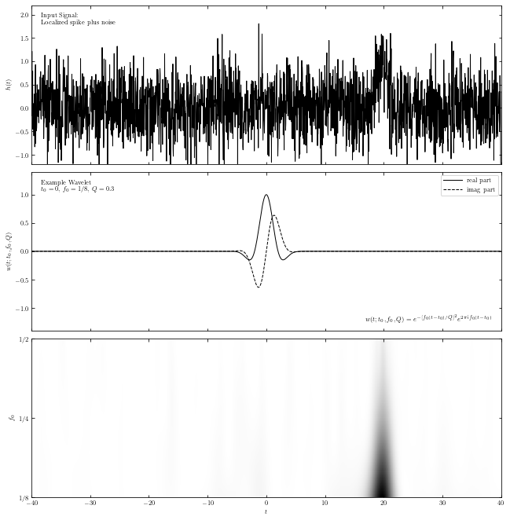

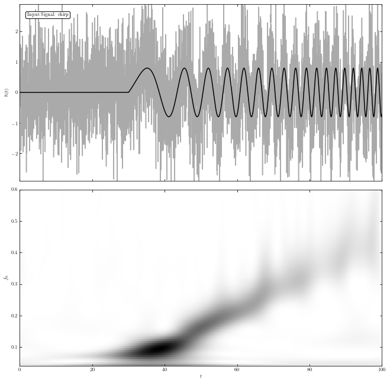

## 2.3 Digital Filtering

Goal: reduce noise or compress time series data

Examples:

- **Low Pass Filtering:** suppress high frequencies
- **High Pass Filtering:** suppress low frequencies
- Passband Filtering: finite range of frequencies admitted
- Notch Filtering: finite range of frequencies is blocked

Fourier and wavelet analysis can be used as filtering techniques

**Main Caveat:** always decreases the information/content of data

- Can be biased in a similar way as binning data with histograms

### Low Pass Filtering

Two Examples:

1. Wiener Filtering: uses Fourier techniques but will only work for evenly sampled data
2. Savitzky-Golay Filtering: fits low-order polynomials by using sliding windows

**Note:** These methods do not set the frequency space you want to exclude as zero since that can produce "ringing" or unwanted osciallations in the signal

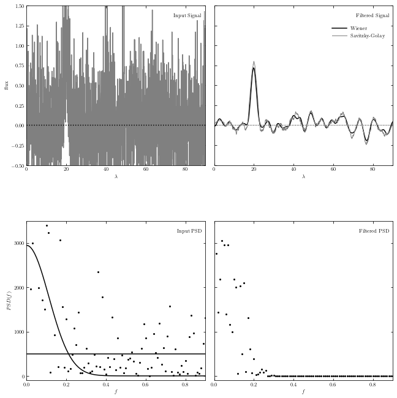

### High Pass Filtering

- Only one example, baseline estimate in spectral data, which has no universally accepted/defined function
- First step toward estimating model parameters of spectral lines (location, width, strength)

Minimum Component Filtering:

1. Determine which regions to exclude and fit a baseline model (like a polynomial) to the rest of the data
2. Apply discrete Fourier transform
3. Remove high frequencies using a low-pass filter and apply an inverse Fourier transform to the result
4. Add the baseline fit that was previously subtracted to the result from the inverse Fourier transform

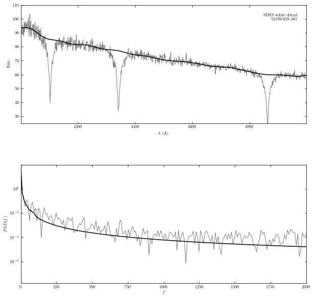

## 3. Summary

#### Main Tasks for Time Series Analysis:

1. Characterize the correlation and significance between different values of $y$
2. Predict future values of $y$

#### Main Set of Toolkits:

Time Domain:

- Signal Detection: Parameter Estimation, Regression, Classification Methods
- Modeling: Bayesian Model odds ratio, AIC criteria, BIC criteria

**Frequency Domain:**

- Fourier Analysis (periodic)
- Discrete Fourier Transforms (periodic)
- Wavelet Analysis (nonperiodic)
- Digital Filtering (way of applying Fourier and Wavelet analysis to reduce noise)

*Next two lectures will go into more detail regarding the types of variability and how to apply these toolkits to specific examples*

## 4. Research Application:

### Quasars

- Most luminous type of AGN -- among the most luminous objects in the universe
- Basic Structure -- accretion disk surrounding a Supermassive Black Hole at the center of galaxies which produces ionizing radiation
- Inner Regions -- accretion disk, dust torus, and broad emission line region all directly affected by the SMBH but on scales that can't be spatially resolved (sub-parsec scales for $10^8 M_\odot$ SMBH)

[figure not shown]

Time series analysis can provide observational constraints on these regions that can't be spatially resolved

### Reverberation Mapping

- Determines the characteristic size of broad emission line regions by measuring the time delay of the broad-line regions in quasar spectra as the mean light-travel time across the broad-line region

[figure not shown]

ref. 2

### Reverberation Mapping Results and Importance

Results:

- Estimate SMBH masses by combining this characteristic size with the velocity dispersion of the broad-line emission regions (determined from the width of the broad-line regions)
- Can determine more detailed structure/kinematics of the broad-line region through modeling methods

Importance:

- Better study accretion processes and how feedback can effect the host galaxies and surrounding circumgalactic medium
- Better constrain possible coevolution between SMBHs and their host galaxies
- Understanding SMBHs throughout various epochs

### Changing-Look Quasars:

[figure not shown]

  ref. 3

### Changing-Look Quasars and Problems with Current Theory

- Shows changes over time in accretion rate/flow
- Presents problems for the current unified model of AGN and the Standard Accretion Disk Theory

Unified Model of AGN:

- Explains that the characteristics separating different classes/types of AGN are due to the geometry of the SMBH's surroundings
- Changing-Look Quasars challenge this since its intrinsic geometry relative to the observer shouldn't change

Standard Accretion Disk Theory:

- Observed timescale of these changes is much shorter than what is currently required by the standard accretion disk theory to significantly change the accretion rate
- Highlighted since these changes are taking place in only a few years when considered from the quasar rest frame

### Future with Changing-Look Quasars

- New way to study accretion disk structure and environments
- Can probe changes in quasar continuum emission
- New way to study the stucture of broad-line regions
- Current (SDSS) and future (LSST) surveys will continue to find more of these objects

### SMBH Binaries

- Expected result from hierarchical galaxy formation models
- Predicted main source of nanofrequency gravitational waves
- Changes in the light curves of these candidates are consistent with binary motion (Graham et al. 2015a, b)

[figure not shown]

ref. 3

### SMBH Binaries

Physical mechanisms for the periodicity aren't easily identifiable:

1. Jet Precession
2. Warped Accretion Disks
3. Relativistic Doppler Boosting
4. Periodic Accretion

All methods listed imply a binary system and aren't easily accountable with single SMBH models

### Reserach Summary

Time series analysis can provide observational constraints on regions near the SMBH of quasars that can't be spatially resolved

1. Reverberation Mapping
2. Changing-Look Quasars
3. SMBH Binaries

Allows for better studies regarding SMBHs, galaxy evolution, coevolution of galaxies and their SMBHs, how accreting SMBHs affect the circumgalactic medium

### References

1. [Shen et al. 2019](https://arxiv.org/pdf/1903.04533.pdf)
2. [Lira et al. 2018](https://arxiv.org/pdf/1806.08358.pdf)
3. [Graham et al. 2017](https://arxiv.org/pdf/1612.07271.pdf)
4. [SDSS Reverberation Mapping Program (eBOSS)](https://www.sdss.org/dr15/algorithms/ancillary/reverberation-mapping/)
5. [Image Credit for Quasar Art: NASA, ESA and J. Olmsted (STScI)](https://www.nasa.gov/feature/goddard/2020/quasar-tsunamis-rip-across-galaxies)